# Lab 2: R Markdown and Basic Objects

Author

Ryan Fernald

In this lab, you will familiarize yourself with R Markdown, file management, and basic objects and functions. **Follow the instructions below and use R Markdown to create a pdf document with your code and answers to the following questions on Gradescope.** You may find a template file by clicking “Code” in the top right corner of this page.

Your final submission should clearly include all code needed to generate your answers and should be formatted according to the guidelines outlined in class. In particular, make sure:

1. Code and output are clearly organized by question.
2. Unnecessary messages, warning, and output are removed.

You may collaborate with your classmates and consult external resources, but you should write and submit your own answer. **Any classmates with whom you collaborate should be credited at the top of your submission. Similarly, if you consult any external references, you should cite them clearly and explicitly.**

## A. File paths and Introduction to R Markdown

```r
getwd()
```

```
[1] "/Users/chuck/Documents/MATH167R/labs"
```

2. In the console, run the command `getwd()`. What is the output? If it is different from your answer to Question 1, why? Explain, in your own words, what the working directory is.

When I use getwd() in my console it returns the file path `"/Users/chuck"` which is different from the output to the R markdown file. I think this is because the console is taking the working directory from where R is installed instead of where the Markdown file is saved. When the R markdown file is rendered or knitted it will pull the working directory from the location in which the file is saved.

3. Every time you Render/Knit your Rmd document, **all** of the code is run in a **new** R session. Any code run in the interactive session **does not affect** your rendered html file. Create a code chunk below that sets the value of `x` to be your favorite number and then uses `print(x)` to print it out.

```r
x <- pi
print(x)
```

```
[1] 3.141593
```

4. Download [this dataset](https://www.openintro.org/data/csv/cars.csv) to your `data` folder, then use a code chunk with the code `cars <- read.csv("YOUR PATH HERE")` to open the file. You will need to replace the text `YOUR PATH HERE` with the correct location of the dataset to open this successfully.

```r
cars <- read.csv("/Users/chuck/Documents/MATH167R/data/cars.csv")
```

5. Run the code `head(cars)` in a code chunk to display the first few rows of this dataset.

```r
head(cars)
```

```
  speed dist
1     4    2
2     4   10
3     7    4
4     7   22
5     8   16
6     9   10
```

## B. Vectors and Matrices

6. Write a line of code to generate a vector of length 100 whose entries are 1, 2, …, 100.

```r
w <- c(1:100)
#print(w)
```

7. Write a line of code to generate the following matrix:

`1 2 3`

`4 5 6`

`7 8 9`

```r
x <- c(1:3)
y <- c(4:6)
z <- c(7:9)
my_matrix <- matrix(c(x, y, z), nrow = 3, ncol = 3, byrow = TRUE)
my_matrix
```

```
     [,1] [,2] [,3]
[1,]    1    2    3
[2,]    4    5    6
[3,]    7    8    9
```

## C. Working with Data Frames

Use the following code to load the `penguins` data.

```r
# load palmer penguins package
library(palmerpenguins)

# open penguins data as a data frame
data(penguins)
penguins <- as.data.frame(penguins)
```

8. Using the `mean()` function, compute the mean body mass of penguins in the dataset, dropping any missing values.

[I found the paste method here.](https://www.programiz.com/r/print-output#I)

[I found the round method here.](https://thomasleeper.com/Rcourse/Tutorials/numeric-printing.html) Rounded to 2 decimal places.

```r
average_body_mass <- round(mean(penguins$body_mass_g, na.rm = T),2)
print(paste("Average body mass", average_body_mass,"grams."))
```

```
[1] "Average body mass 4201.75 grams."
```

9. Using the `max` function, compute the maximum flipper length of penguins in the dataset, dropping any missing values.

```r
max_flipper_length <- max(penguins$flipper_length_mm, na.rm = T)
print(paste("Largest flipper length:", max_flipper_length, "millimeters."))
```

```
[1] "Largest flipper length: 231 millimeters."
```

10. Using the `hist` function, create a histogram of the ratio of the penguins’ bill length to bill depth, dropping any missing values. What is the shape of the reuslting distribution?

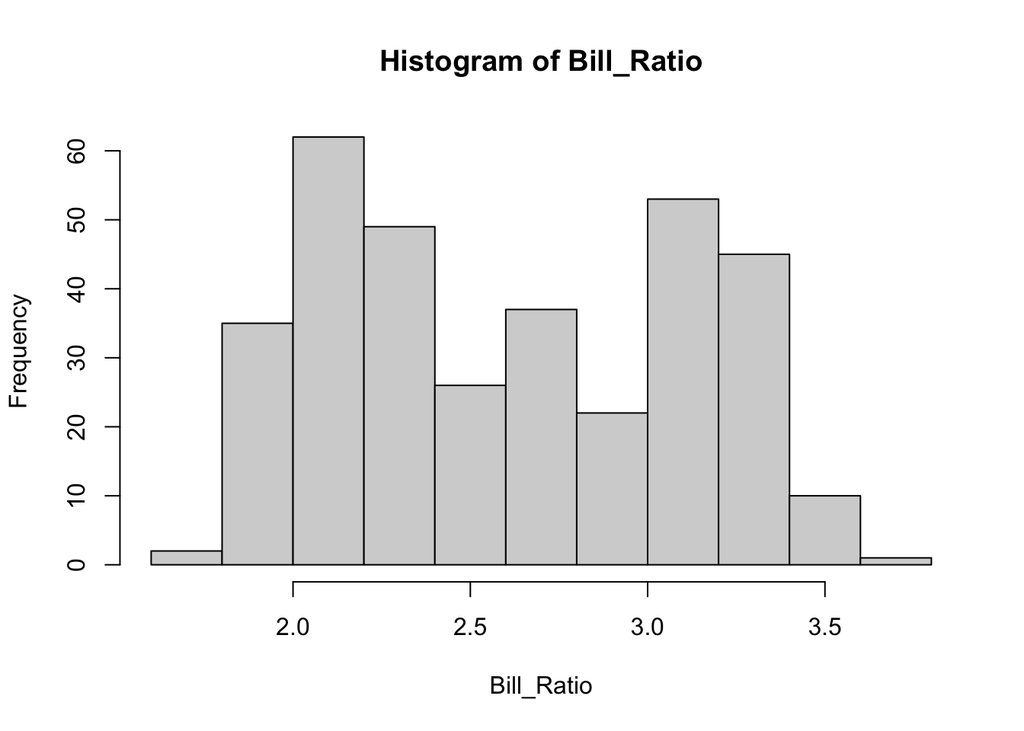

```r
Bill_Ratio <- penguins$bill_length_mm / penguins$bill_depth_mm
hist(Bill_Ratio)
```

It looks like we have some data that is bi-modal, which means it has two humps. To test this I want to see if there is a difference between male and female for their bill ratio’s.

Looking ahead at lecture 5 for filtering and using the [subset()](https://www.statmethods.net/management/subset.html) method:

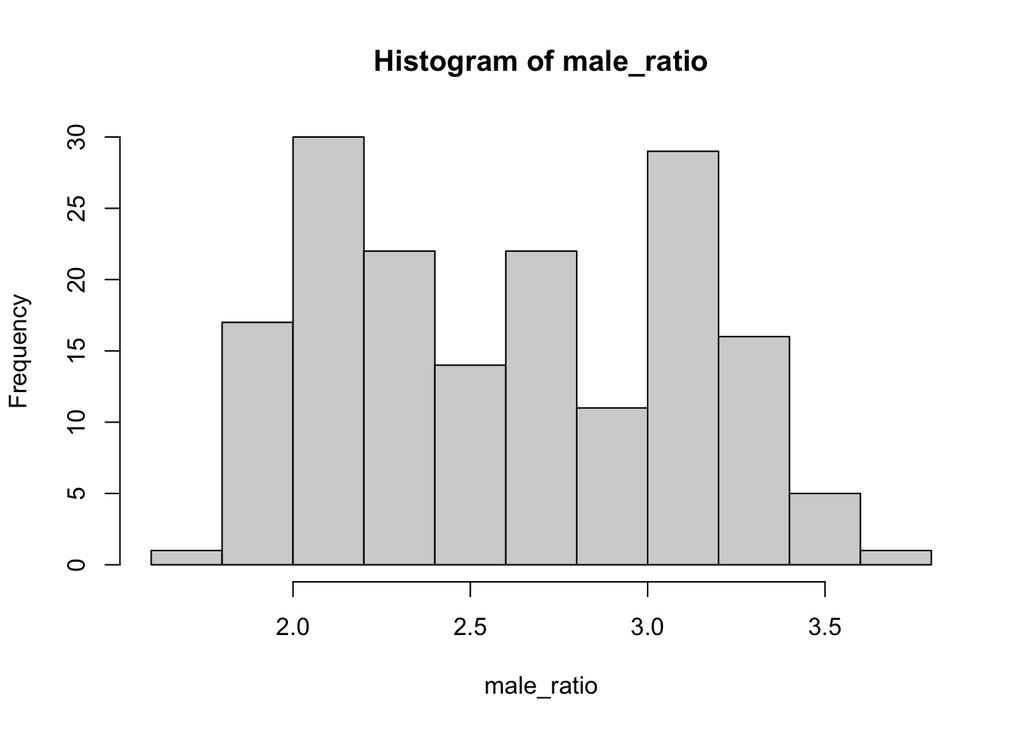

```r
male_data <- subset(penguins, sex == "male")
male_ratio <- male_data$bill_length_mm / male_data$bill_depth_mm
hist(male_ratio)
```

Interesting that it looks about the same, I’ll check the female just to be sure, but by logic it should also look the same:

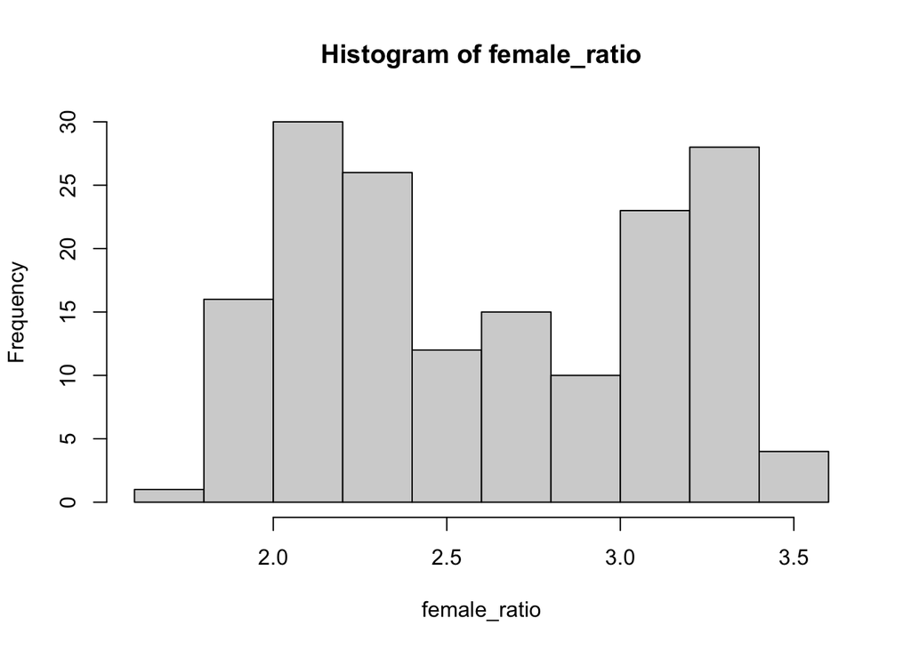

```r
female_data <- subset(penguins, sex == "female")
female_ratio <- female_data$bill_length_mm / female_data$bill_depth_mm
hist(female_ratio)
```

As expected it looks about the same, so I’ll check for another reason. It looks like we only have three islands in our data set so I’ll check for to see if it’s geographic and thus a different habitat / climate that would cause this bi-modal distribution.

```r
Biscoe_data <- subset(penguins, island == "Biscoe")
Dream_data <- subset(penguins, island == "Dream")
Torgersen_data <- subset(penguins, island == "Torgersen")

Biscoe_ratio <- Biscoe_data$bill_length_mm / Biscoe_data$bill_depth_mm
Biscoe_mean <- round(mean(Biscoe_ratio, na.rm = T),3)
Biscoe_num <- nrow(Biscoe_data)
Biscoe_unique_species_num <- length(unique(Biscoe_data$species))
print(paste("Biscoe average bill ratio", Biscoe_mean, "with", Biscoe_num, "samples and", Biscoe_unique_species_num, "unique species"))
```

```
[1] "Biscoe average bill ratio 2.899 with 168 samples and 2 unique species"
```

```r
Dream_ratio <- Dream_data$bill_length_mm / Dream_data$bill_depth_mm
Dream_mean <- round(mean(Dream_ratio, na.rm = T),3)
Dream_num <- nrow(Dream_data)
Dream_unique_species_num <- length(unique(Dream_data$species))
print(paste("Dream average bill ratio",Dream_mean,"with", Dream_num, "samples and", Dream_unique_species_num, "unique species"))
```

```
[1] "Dream average bill ratio 2.41 with 124 samples and 2 unique species"
```

```r
Torgersen_ratio <- Torgersen_data$bill_length_mm / Torgersen_data$bill_depth_mm
Torgersen_mean <- round(mean(Torgersen_ratio, na.rm = T),3)
Torgersen_num <-nrow(Torgersen_data)
Torgersen_unique_species_num <- length(unique(Torgersen_data$species))
Torgersen_unique_species <- unique(Torgersen_data$species)
print(paste("Torgersen average bill ratio",Torgersen_mean, "with", Torgersen_num, "samples and", Torgersen_unique_species_num, "unique species"))
```

```
[1] "Torgersen average bill ratio 2.121 with 52 samples and 1 unique species"
```

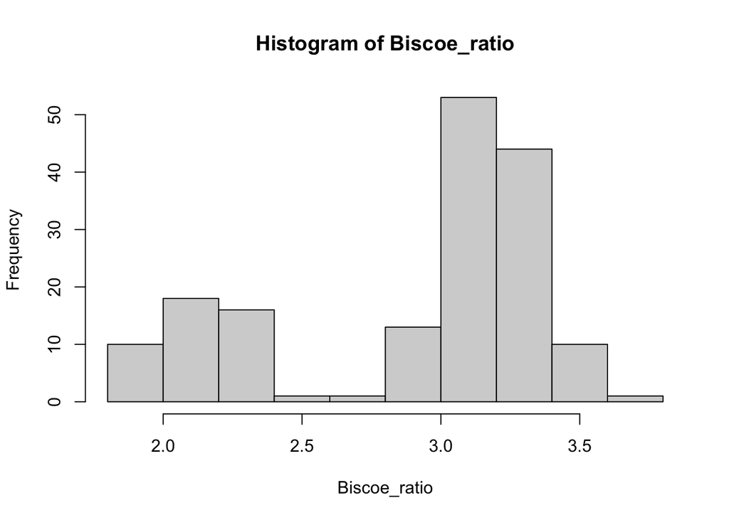

```r
hist(Biscoe_ratio)
```

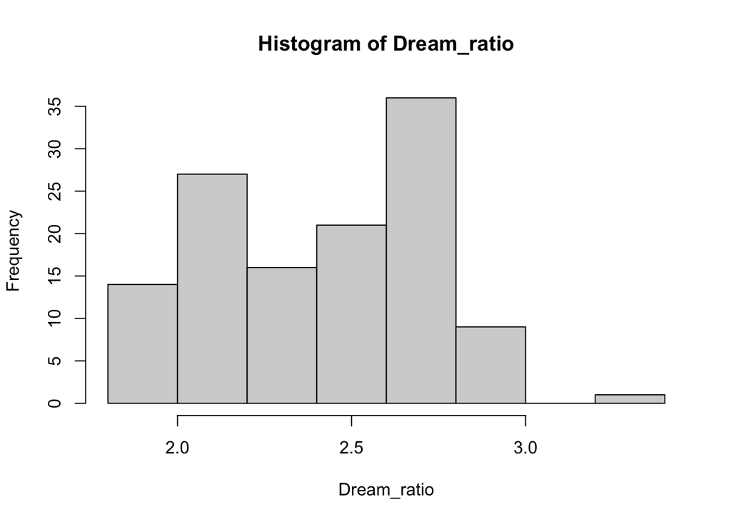

```r
hist(Dream_ratio)
```

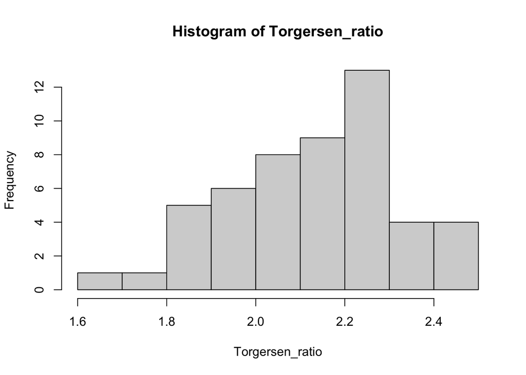

```r
hist(Torgersen_ratio)
```